# Does Risk-Based Inspection Fill the Gaps the Mandatory System Left Behind?

FDNY RBIS, Mandatory Inspections, and Structural Fires by Council District — First Draft

NYC Council Data Team

July 01, 2026

## Executive Summary

In 2014 the FDNY replaced scheduled inspection cycles with the Risk-Based Inspection System (RBIS), which uses a risk model to direct building inspections toward the structures it scores as most fire-prone. This analysis asks a neutral question: **does RBIS direct inspection resources toward the council districts that the mandatory inspection system (MIFC) under-served relative to their fire levels?**

Three findings, in order of confidence:

1. **RBIS tracks fire levels overall.** Districts with higher pre-2014 structural fire rates receive more RBIS inspections per building (r = 0.88 across 51 districts), and no district is significantly under-inspected relative to its fire level. The only significant deviations run the other way — over-inspection.
2. **But net of fire levels, RBIS partly carries over the mandatory system’s coverage imbalances rather than correcting them.** Districts that received less mandatory coverage than their fire levels predict tend to receive less RBIS coverage too — a moderate but robust association (r = -0.52, p < 0.001), not a one-to-one match. Citywide, RBIS allocation is unrelated to the prior coverage gap itself (r = -0.23, not significant).
3. **High-fire districts as a group are over-covered relative to the gap.** Although RBIS allocation is unrelated to the prior coverage gap citywide, the high-fire districts (top tercile of pre-2014 fire rate) collectively receive RBIS coverage significantly above what their gap predicts (+0.069 inspections per building, p < 0.001; robust to dropping the single largest district, +0.062). RBIS allocates by fire level over and above the legacy mandatory-inspection pattern. (A district-by-district outlier test flags only one district on its own, because a coherent bloc above the line masks its members individually; the group test recovers the bloc.)

Evidence that RBIS *reduced* fires in the districts it targeted is **not established** by this analysis. High-fire districts were already on a long secular fire decline before 2014, violating the parallel-trends assumption the event study requires; the apparent post-2014 effect disappears once each district is given its own time trend, and a placebo test reproduces the “effect” in a period with no treatment. The finding is a limit of the observational design, not evidence that RBIS is ineffective.

## Background

- **MIFC** — Mandatory Inspections by Fire Companies: inspections required by building/occupancy category on fixed cycles, regardless of measured risk.
- **RBIS** — Risk-Based Inspection System (introduced 2014): an algorithmic risk model ranks buildings and fire companies inspect the highest-scoring structures first.
- **FIDD** — Fire Incident Dispatch Data: structural fire incidents, used here as the measure of realized fire risk.

All measures are aggregated to council district (CD) × year and normalized to rates per building using annual MapPLUTO building counts.

RBIS begins in 2014 and ramps up over the following years; the mandatory program continues alongside it. The analysis below treats the pre-2014 period as the mandatory-only baseline and the post-2014 period as the risk-based era.

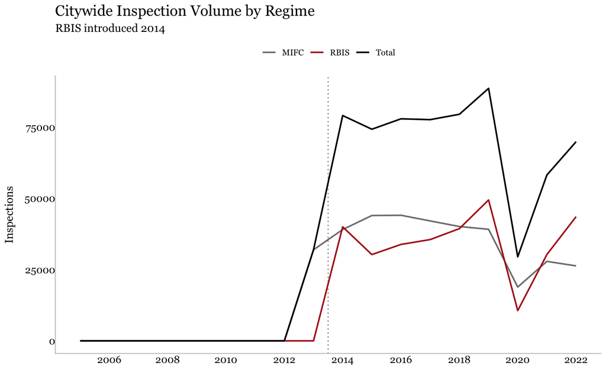

Citywide inspection volume by regime. RBIS begins in 2014 and grows; the mandatory program continues.

## Data and Methods

| Source | NYC Open Data ID | Role |
| --- | --- | --- |
| RBIS inspections | `itd7-gx3g` | Treatment: risk-based inspection activity |
| Mandatory inspections (MIFC) | `kfgh-h6re` | Baseline coverage regime |
| Fire Incident Dispatch Data | `8m42-w767` | Outcome: structural fires |
| MapPLUTO (annual vintages) | — | Denominator: buildings per CD per year |
| CouncilCount (ACS) | — | District demographics |

Fires and inspections are assigned to council districts using each dataset’s own coded `citycouncildistrict` field, as published in NYC Open Data. (An alarm-box-to-PLUTO geocoding routine exists for optional block-level analysis in `01b_block-geocoding.R`, but the district-level analysis here does not use it.)

Two constructed district-level measures drive the targeting analysis:

- **Gap dose** — how much *less* mandatory coverage a district received than its fire level predicts. Computed as the (sign-flipped) residual of a log-log regression of the MIFC rate on the fire rate across districts. The MIFC rate uses 2013 — the first and only pre-RBIS year in the mandatory-inspection dataset — and the fire rate pools 2005–2013. The 2013 baseline is representative, not idiosyncratic: MIFC’s cross-district allocation is structurally stable, and 2013 correlates with every later MIFC year at Spearman ρ ≥ 0.88. The log-log form is required because coverage scales super-linearly with fire rate in levels. The measure is robust to functional form: a rank-based version (fire rank minus coverage rank) agrees with Spearman ρ = 0.93.
- **RBIS-exposure dose** — each district’s mean post-2014 RBIS inspections per building: what RBIS actually did, rather than what any risk score said.

Both measures collapse multiple years into one number per district, which is only valid if district fire risk is stable over time. It is: ranking districts by structural fire rate is almost perfectly stable year to year (Spearman 0.99–1), and the 2005-vs-2022 ranking — 17 years apart — still correlates ρ = 0.96. The districts that burn most do not change. This persistence is also what makes risk-based targeting coherent in principle: the high-need districts are identifiable years in advance, so a persistently under-served high-fire district cannot be explained away by shifting fire risk.

## Fire Risk and Demographics

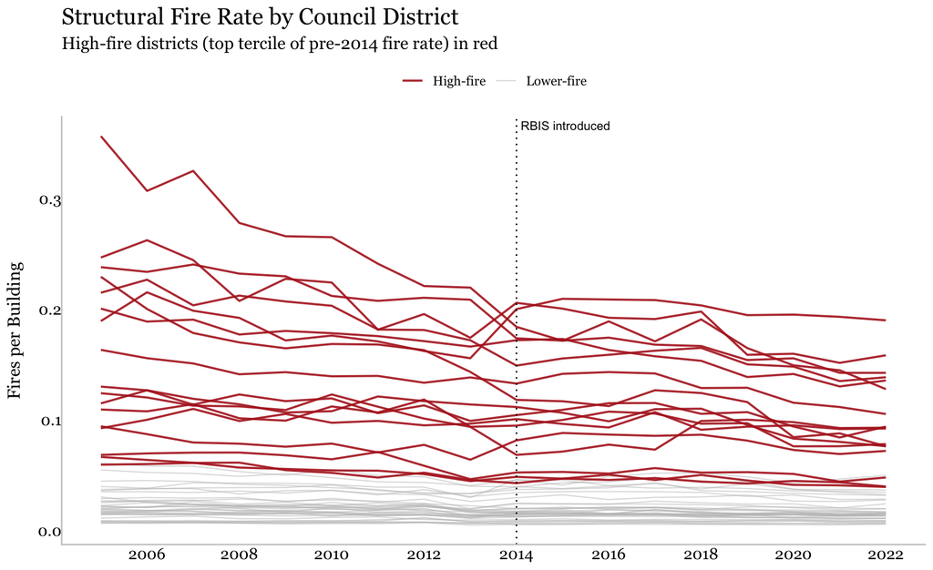

Structural fire rate by council district over time, high-fire districts (top tercile of pre-2014 rate) highlighted.

Structural fire rates vary several-fold across districts and decline citywide over the study period. The high-fire districts highlighted above — the top tercile of pre-2014 fire rates — are the group the rest of the analysis follows, and they differ demographically from the rest of the city. (District demographics use 2013-boundary ACS estimates, matching the pre-2023 boundaries the fire and inspection data sit on.)

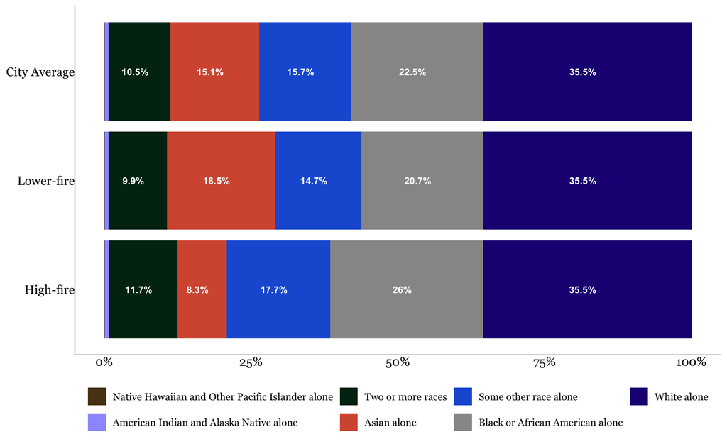

Demographic composition: high-fire districts vs. city average.

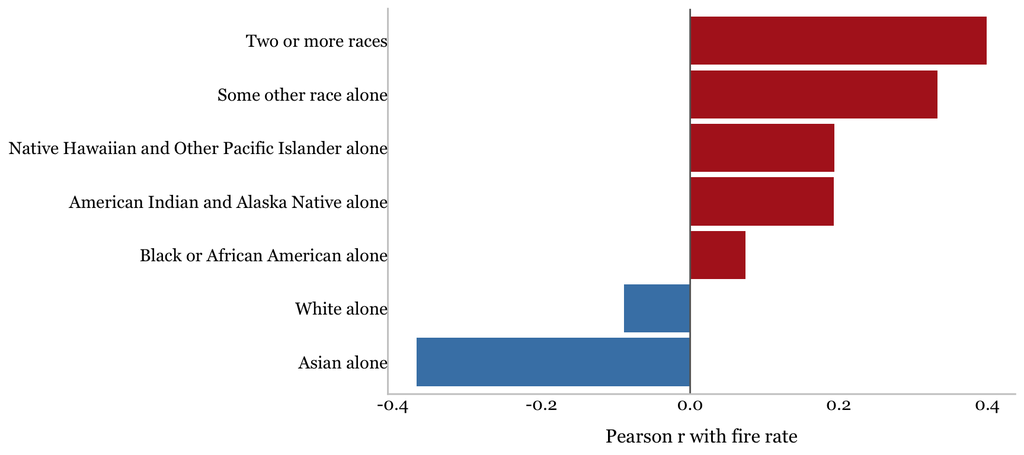

Correlation between district demographic shares and structural fire rates.

The pattern is not a simple white / non-white split — the White share is essentially flat across high- and lower-fire districts (r = -0.09). The clearest signals are an **under-representation of Asian residents** in high-fire districts (8.3% vs. 18.5% in lower-fire districts; r = -0.37) and an over-representation of residents reporting “two or more races” (r = 0.4) or “some other race” (r = 0.33).

This is a cross-sectional association, not a causal claim: demographics proxy for housing stock, density, and income, which are the plausible drivers of fire risk. It establishes that inspection allocation is an equity question.

> **Note on race categories.** “Some other race” and “two or more races” are the ACS race categories where much of the Hispanic/Latino population is recorded (Hispanic origin is collected as a separate ethnicity question), so their positive correlations with fire rate likely partly reflect Hispanic share. A direct Hispanic-origin measure would be needed to disambiguate this.

## The Coverage Gap (Setup)

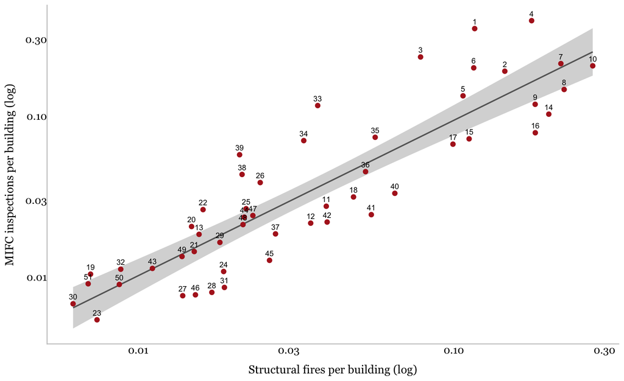

Pre-2014 mandatory inspection coverage vs. fire rate, one point per district (log-log).

Mandatory coverage rises with fire rate on average — the mandatory system was not blind to risk. But districts scatter around the line, and the residual is the policy-relevant quantity: districts **below** the line received less mandatory coverage than districts with comparable fire levels. In the most under-served cases the shortfall reaches roughly 54% less coverage than the district’s fire level predicts.

## Finding: How RBIS Allocates Inspections (Tracks Fires, Mirrors the Old Gaps)

Districts with higher pre-2014 fire rates get more RBIS inspections per building (r = 0.88): the risk model does send inspectors toward fire-prone districts. Per building is the right unit here — RBIS inspects buildings and fires happen in buildings. Much of this link reflects building stock: districts with fewer, older buildings have both more fires and more inspections per building. Net of building stock the association is weaker but still positive (partial r = 0.27).

The same holds when each district is tested individually. Regressing RBIS coverage on fire rate and flagging districts that depart from the line (studentized residuals, false-discovery-rate corrected across all 51 districts), **0 districts are significantly under-inspected relative to their fire level** — no high-fire district is being left behind. The only significant departures run the other way — over-inspection. The most pronounced is a single district dominated by commercial and high-rise occupancy, which receives roughly 2.1× the RBIS coverage its fire rate predicts (0.171 vs. 0.083 inspections per building) — likely reflecting the risk model’s weighting of commercial and high-rise occupancy rather than residential fire incidence (see table).

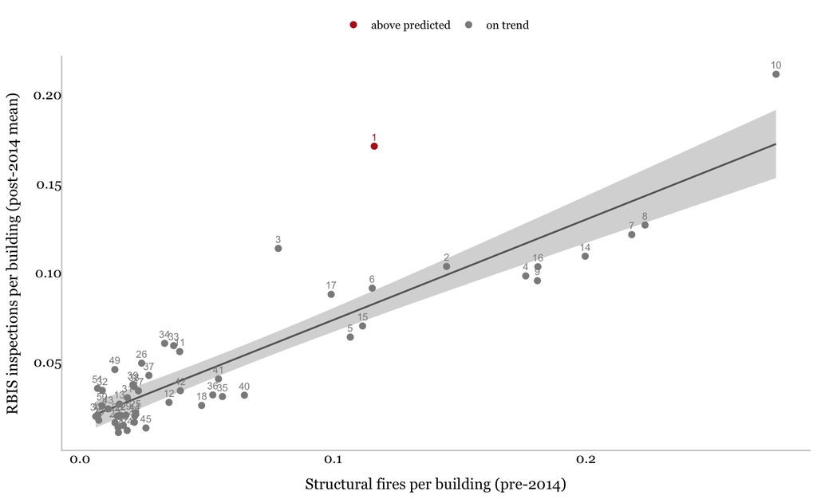

RBIS coverage vs. pre-2014 fire rate. RBIS coverage rises with fire; the only significant outlier is over-inspection (red).

Districts significantly over-inspected relative to their structural fire rate (FDR < 0.05). No district is significantly under-inspected.

| Council District | Fires per building (pre-2014) | RBIS per building | Predicted from fire rate | p (FDR) |
| --- | --- | --- | --- | --- |
| 1 | 0.116 | 0.171 | 0.083 | 0 |

So on the fire-to-inspection dimension RBIS broadly does its job. The gap-filling hypothesis, however, requires more — that RBIS *preferentially* covers the districts the mandatory system left behind. Two comparisons answer two different questions: whether RBIS *fills* the gap, and what its allocation looks like *relative to* the gap. RBIS neither fills the gap nor is neutral to it — it does not send more inspections to the under-served districts, and net of fire it partly mirrors the old coverage pattern.

- *Does RBIS fill the gap?* RBIS exposure vs. prior coverage gap: r = -0.23 (n.s.) — no systematic relationship. RBIS does not preferentially cover the under-served districts.
- *What is the pattern instead?* A residual-to-residual comparison purges fire levels from both sides — each regime’s coverage is regressed on fire rate first, and the leftovers are correlated. The correlation between RBIS coverage net of fire and the prior gap is **r = -0.52 (p < 0.001)** — negative. Districts the mandatory system over-covered relative to their fires *tend to be* the ones RBIS over-covers too. This is a moderate but robust association, not a lockstep: it accounts for about 27% of the variation, leaving most of it district-specific. The two regimes partly share an allocation pattern; plausibly both are driven in part by the same building-stock and occupancy characteristics rather than by realized fire incidence.

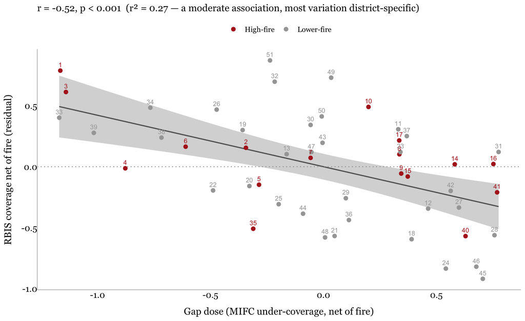

RBIS coverage net of fire vs. the prior coverage gap (both fire-adjusted). The downward slope is the residual-to-residual association.

The slope of that scatter is the −0.52 correlation: districts the mandatory system under-served (right) tend to get less RBIS than their fire level predicts (lower), and vice versa.

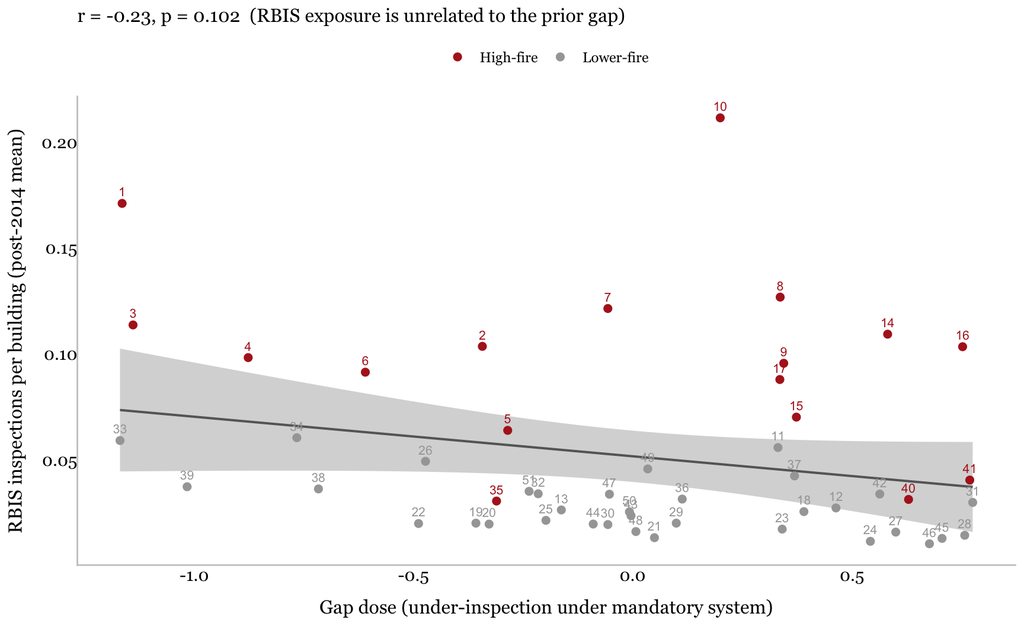

RBIS exposure vs. prior under-inspection gap, high-fire districts highlighted. The gap-filling hypothesis predicts an upward slope.

A cluster of points sits visibly above the weakly-negative line. A district-by-district outlier test flags only one of them, because a coherent group above the line pulls the fitted line toward itself and deflates each member’s residual (masking). Testing the bloc directly — adding a high-fire indicator (defined on fire rate, exogenous to RBIS) to the regression — confirms the pattern: high-fire districts as a group receive **+0.069 inspections per building above what their gap predicts (p < 0.001)**, robust to dropping the single largest district (+0.062). The reading is consistent with the rest of this section: RBIS does not fill the mandatory system’s relative gaps, but it does allocate by fire level, which lifts the high-fire bloc above the gap line.

These two results are not in tension. They sit on different axes. *Between* fire levels, RBIS follows fire — high-fire districts get more, which is why the bloc floats above the line. *Within* a fire level, RBIS reproduces the mandatory system’s relative shortfalls — the districts MIFC under-served stay under-served. In the same regression both appear together: the fire-group term is positive (+0.069) while the gap term is negative. Concretely, a high-fire district that the mandatory system also under-served still receives more RBIS than a low-fire district (fire wins) but less than a high-fire district the mandatory system covered fully (the gap persists). The high-fire bloc sits high because of its fire level, not because RBIS corrected the gap.

Ten most under-served districts under the mandatory system, with their RBIS coverage.

| Council District | Gap dose (higher = more under-served pre-2014) | RBIS inspections per building |
| --- | --- | --- |
| 31 | 0.77 | 0.030 |
| 41 | 0.77 | 0.040 |
| 28 | 0.76 | 0.014 |
| 16 | 0.75 | 0.103 |
| 45 | 0.70 | 0.013 |
| 46 | 0.68 | 0.010 |
| 40 | 0.63 | 0.031 |
| 27 | 0.60 | 0.016 |
| 14 | 0.58 | 0.109 |
| 42 | 0.56 | 0.034 |

### Geographic view

The same allocation seen on the map: each district shaded by inspections per building, with structural-fire rates as overlaid icons (larger = more fires). The mandatory baseline (2013) and the risk-based era (2022) are shown separately. (Static snapshots; the interactive version is `03_mapping.R`.)

[figure not shown]

MIFC inspections per building by council district (2013), with structural-fire rates as icons.

[figure not shown]

RBIS inspections per building by council district (2022), with structural-fire rates as icons.

## Finding: Did Fires Fall Where RBIS Went? (No Evidence Either Way)

We fit an event study interacting each district’s RBIS-exposure dose with year indicators, and a two-way fixed-effects model of fire rates on inspection rates at lags 0–3 with district-clustered standard errors (a Wooldridge test confirms serial correlation in the panel residuals). The event study is:

$$\text{fireRate}_{i,t} = \alpha_i +
\gamma_t + \sum_{k \neq 2013} \beta_k\,\big(\text{dose}_i \times
\mathbb{1}[t=k]\big) + \varepsilon_{i,t}$$

for district $i$, year $t$. Here $\alpha_i$ is a district fixed effect (each district compared to itself), $\gamma_t$ a year fixed effect (citywide shocks), $\text{dose}_i$ the district’s time-invariant RBIS-exposure dose, and $\beta_k$ the coefficient for year $k$ — the gap in fire rate per unit of dose, relative to the reference year 2013 (so $\beta_{2013}=0$). The plotted $\beta_k$ should be flat before 2014 and dip below zero after, if RBIS reduced fires. Standard errors are clustered by district.

The naive event study *appears* to show fires falling in high-dose districts after 2014. That reading does not survive scrutiny, for three reasons.

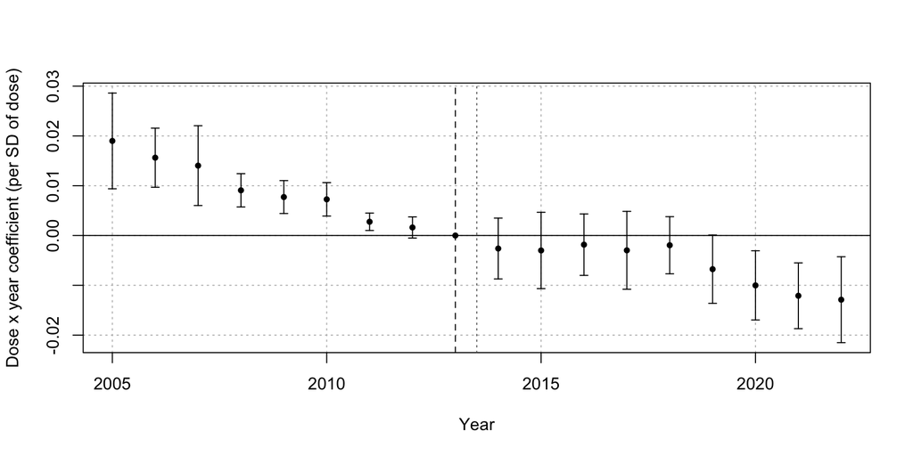

**1. Pre-trends fail.** The pre-2014 coefficients are not flat — high-dose districts were already converging toward the rest of the city, a continuation of the city’s long structural fire decline. Parallel trends, which the causal reading requires, does not hold.

**2. The effect vanishes under district-specific trends.** We give each district its own linear time trend, replacing the district intercept with an intercept *plus* a district-specific slope:

$$\alpha_i \;\longrightarrow\; \alpha_i +
\delta_i\, t$$

so $\delta_i$ is a separate fire-rate trend for each district. The $\beta_k$ now measure fire rates *relative to each district’s own trajectory*, and a real effect would show as a bend away from that trend at 2014. Instead the coefficients scatter around zero — fires landed where each district’s pre-existing decline predicted. The apparent post-2014 drop was the trend, not RBIS.

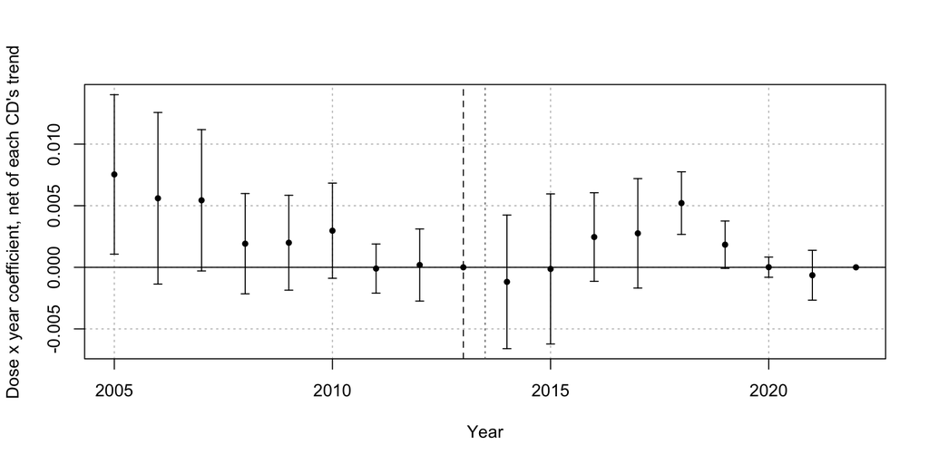

Event study with district-specific linear trends. The post-2014 effect disappears.

**3. A placebo finds a spurious effect.** Pretending RBIS launched in 2010 and using only pre-2014 data — when nothing happened — the same design still “detects” a significant fire decline in high-dose districts. A method that finds an effect where none can exist cannot be trusted to measure the real one.

**Conclusion:** the event study **cannot establish that RBIS reduced fires**, in either direction. The post-2014 pattern is an artifact of the secular fire decline in the districts RBIS targets. This is a limitation of the observational design, not evidence that RBIS is ineffective.

The distributed-lag model is the more credible causal-adjacent test. It uses *annual* inspection rates (not a static dose) and lags them:

$$\text{fireRate}_{i,t} = \alpha_i +
\gamma_t + \sum_{L=0}^{3} \beta_L\,\text{inspRate}_{i,\,t-L} +
\varepsilon_{i,t}$$

where $\text{inspRate}_{i,\,t-L}$ is the combined MIFC + RBIS inspection rate in district $i$, $L$ years before year $t$, and $\beta_L$ is its effect on the current fire rate (district and year fixed effects, district-clustered standard errors). The same-year term $\beta_0$ is contaminated by simultaneity — inspectors are sent *because* fires are occurring — so the causally meaningful terms are the lags $\beta_1,\beta_2,\beta_3$: past inspections precede current fires, so a negative lagged coefficient would mean inspections reduce *future* fires.

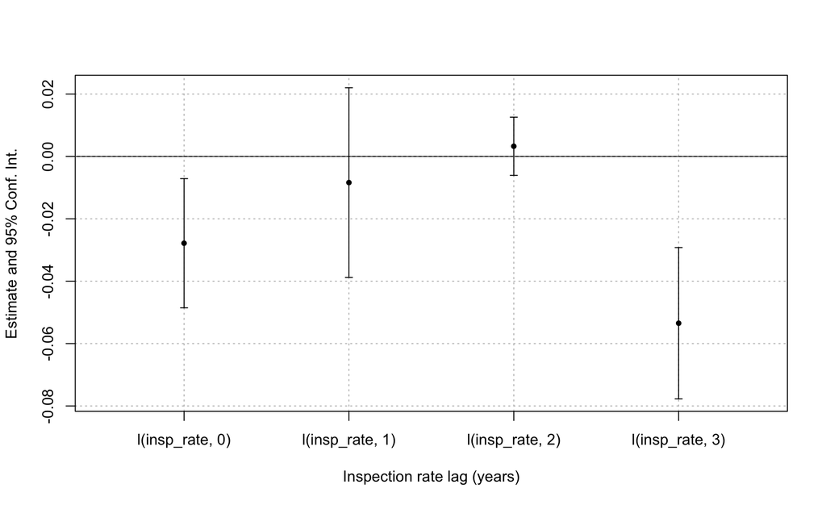

Distributed-lag estimates: inspection rate vs. fire rate, lags 0-3, district and year fixed effects.

Its estimates are mixed and mostly weak. The lagged terms — the ones that break same-year simultaneity — show no significant association at one or two years (b = -0.008 and 0.003, both n.s.); only the three-year lag is negative and significant (b = -0.053, p < 0.001, and stable when a building-stock control is added). An effect that appears at three years but not at one or two is inconsistent, so this is suggestive at most — not strong evidence that inspections reduce fires. (Full estimates, including a Poisson specification with a log-buildings offset, are in `04_analysis.R`.)

The allocation findings above stand independently of this section: they concern how inspections are *allocated*, not whether they *reduce* fires.

## Next Steps

- Save final figures to `visuals/` and add map panels from `03_mapping.R` (gap dose and RBIS dose choropleths).
- Confirm 2013 reference-year anomaly in the fire series before finalizing event-study figures.
- Quantify the overlap between the MIFC and RBIS source records, which underpins the mandatory-versus-risk-based framing.

## Addendum: High-Fire Defined as Top Quartile

The main analysis defines “high-fire” as the **top tercile** (top third) of pre-2014 fire rate. As a sensitivity check, this addendum redefines it as the **top quartile** (top 25%) and re-runs the outputs that depend on that cut. Results that do not use the grouping — the demographic-vs-fire-rate correlation, the coverage gap, RBIS-vs-fire, and the event study — are unchanged, because they use the continuous fire rate, not the high/low label.

The quartile cut labels **13** districts high-fire (versus **17** under the tercile) — a narrower, more extreme group.

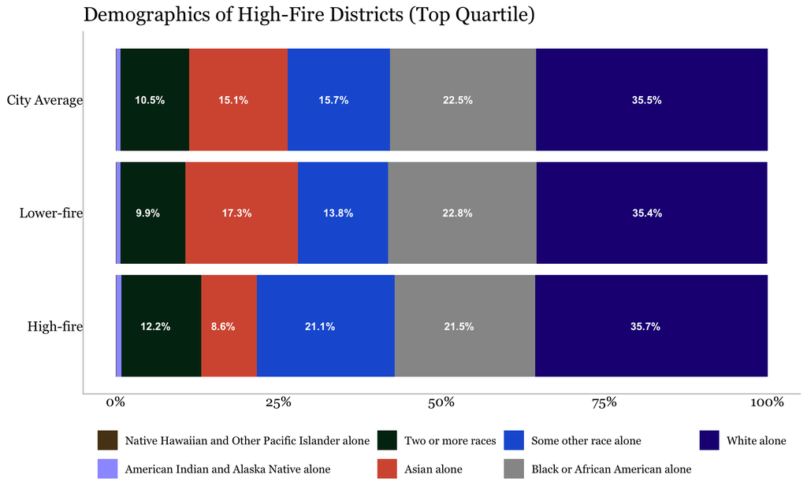

Demographic composition of high-fire districts, top-quartile definition.

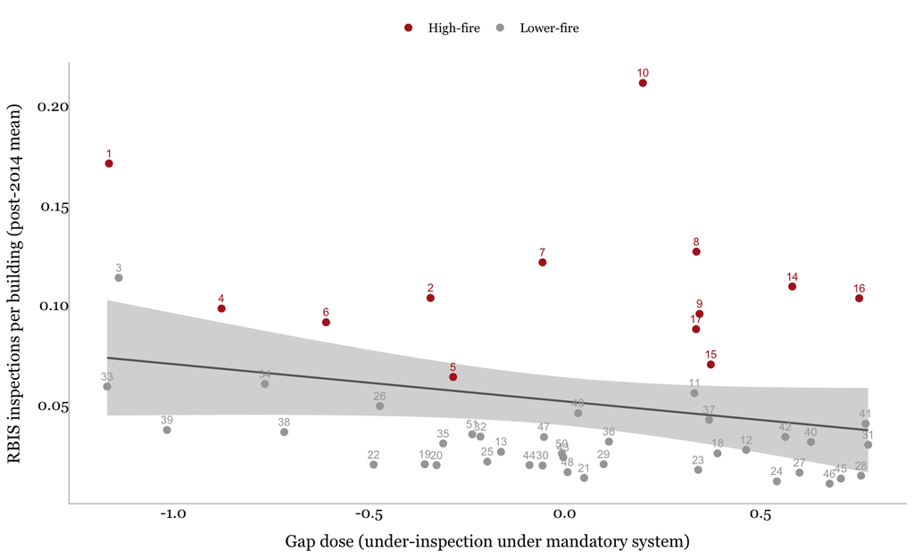

RBIS exposure vs. gap, high-fire districts by the top-quartile definition.

The group test still holds under the narrower definition: the high-fire bloc sits **+0.08** inspections per building above the RBIS-vs-gap line (p < 0.001), compared with **+0.069** under the tercile. The substantive conclusion — RBIS allocates by fire level over and above the legacy pattern — is not sensitive to where the high-fire threshold is drawn.